# Introduction to R

DS 501

## Introduction

- R is a software language for carrying out complicated (and simple) statistical analyses.
- It includes routines for data summary and exploration, graphical presentation and data modelling.
- When you work in R you create objects that are stored in the current workspace(also called image).
- Each object created remains in the image unless you explicitly delete it.
- At the end of the session the workspace will be lost unless you save it.
- Commands written in R are saved in memory throughout the session.
- You can scroll back to previous commands typed by using the `up` arrow key (and `down` to scroll back again).
- You can also `copy` and `paste` using standard editor techniques.
- You finish an R session by typing `q()` at which point you will also be prompted as to whether or not you want to save the current workspace If you do not, it will be lost.
- If you don’t know how to use a function, or don’t know what the options or default values are, type `help(functionname)`, `?functionname` or `??functionname` where function-name is the name of the function you are interested in. This will usually help and will often include examples to make things even clearer.

## Objects and Arithmetic

R stores information and operates on objects. The simplest objects are scalars, vectors and matrices. But there are many others, lists and dataframes for example.

```r
4+6
```

```
## [1] 10
```

We can assign objects values for subsequent use.

```r
x=6
y=4
z=x+y
```

We can look at the contents of the object by simply typing its name

```r
z
```

```
## [1] 10
```

At any time we can list the objects which we have created

```r
ls()
```

```
## [1] "x" "y" "z"
```

More commonly a function will operate on an object, for example

```r
sqrt(36)
```

```
## [1] 6
```

Objects can be removed from the current workspace with the `rm` function

```r
rm(x,y)
ls()
```

```
## [1] "z"
```

Vectors can be created in R in a number of ways. We can describe all of the elements. Note the use of the function c to concatenate or “glue together” individual elements. This function can be used much more widely.

```r
z = c(5,9,1,0)
z
```

```
## [1] 5 9 1 0
```

```r
x = c(5,9)
y = c(1,0)
z = c(x,y)
z
```

```
## [1] 5 9 1 0
```

Sequences can be generated as follows:

```r
x = 1:10
x
```

```
##  [1]  1  2  3  4  5  6  7  8  9 10
```

```r
seq(1:10)
```

```
##  [1]  1  2  3  4  5  6  7  8  9 10
```

while more general sequences can be generated using the seq command.

```r
seq(1,10,by=2)
```

```
## [1] 1 3 5 7 9
```

```r
seq(8,20,length=6)
```

```
## [1]  8.0 10.4 12.8 15.2 17.6 20.0
```

Another useful function for building vectors is the rep command for repeating things.

```r
rep(0,100)
```

```
##   [1] 0 0 0 0 0 0 0 0 0 0 0 0 0 0 0 0 0 0 0 0 0 0 0 0 0 0 0 0 0 0 0 0 0 0 0
##  [36] 0 0 0 0 0 0 0 0 0 0 0 0 0 0 0 0 0 0 0 0 0 0 0 0 0 0 0 0 0 0 0 0 0 0 0
##  [71] 0 0 0 0 0 0 0 0 0 0 0 0 0 0 0 0 0 0 0 0 0 0 0 0 0 0 0 0 0 0
```

```r
rep(1:3,6)
```

```
##  [1] 1 2 3 1 2 3 1 2 3 1 2 3 1 2 3 1 2 3
```

```r
rep(1:3,c(6,6,6))
```

```
##  [1] 1 1 1 1 1 1 2 2 2 2 2 2 3 3 3 3 3 3
```

```r
rep(1:3,rep(6,3))
```

```
##  [1] 1 1 1 1 1 1 2 2 2 2 2 2 3 3 3 3 3 3
```

R will often adapt to the objects it is asked to work on. R uses componentwise arithmetic on vectors. R will also try to make sense if objects are mixed.

```r
x = c(6,8,9)
y = c(1,2,4)
x+y
```

```
## [1]  7 10 13
```

```r
x*y
```

```
## [1]  6 16 36
```

```r
x+2
```

```
## [1]  8 10 11
```

functions `length` and `sum`

```r
length(x)
```

```
## [1] 3
```

```r
sum(x)
```

```
## [1] 23
```

## Summaries and Subscripting

Lets assume we collected some data from an experiment and stored them in an object x

```r
x = c(7.5,8.2,3.1,5.6,8.2,9.3,6.5,7.0,9.3,1.2,14.5,6.2)
# Mean
mean(x)
```

```
## [1] 7.216667
```

```r
# Variance
var(x)
```

```
## [1] 11.00879
```

```r
# Standard Deviation
sd(x)
```

```
## [1] 3.317949
```

```r
# Summary
summary(x)
```

```
##    Min. 1st Qu.  Median    Mean 3rd Qu.    Max.
##   1.200   6.050   7.250   7.217   8.475  14.500
```

Subset first six observations

```r
x[1:6]
```

```
## [1] 7.5 8.2 3.1 5.6 8.2 9.3
```

```r
x[7:12]
```

```
## [1]  6.5  7.0  9.3  1.2 14.5  6.2
```

```r
x[c(2,4,6)]
```

```
## [1] 8.2 5.6 9.3
```

To exclude particular elements

```r
x[-c(1:6)]
```

```
## [1]  6.5  7.0  9.3  1.2 14.5  6.2
```

## Matrices

Matrices can be created in R in a variety of ways. Perhaps the simplest is to create the columns and then glue them together with the command `cbind` or `rbind`.

```r
x = c(5,7,9)
y = c(6,3,4)
z = cbind(x,y)
z
```

```
##      x y
## [1,] 5 6
## [2,] 7 3
## [3,] 9 4
```

```r
dim(z)
```

```
## [1] 3 2
```

```r
nrow(z)
```

```
## [1] 3
```

```r
ncol(z)
```

```
## [1] 2
```

```r
rbind(z,z)
```

```
##      x y
## [1,] 5 6
## [2,] 7 3
## [3,] 9 4
## [4,] 5 6
## [5,] 7 3
## [6,] 9 4
```

Matrices can also be built by explicit construction via the function `matrix`. The matrix is ‘filled-up’ by columnwise by default.

```r
matrix(c(5,7,9,6,3,4), nrow=3)
```

```
##      [,1] [,2]
## [1,]    5    6
## [2,]    7    3
## [3,]    9    4
```

```r
matrix(c(5,7,9,6,3,4), ncol=3)
```

```
##      [,1] [,2] [,3]
## [1,]    5    9    3
## [2,]    7    6    4
```

```r
z = matrix(c(5,7,9,6,3,4), nrow=3, byrow=T)
z
```

```
##      [,1] [,2]
## [1,]    5    7
## [2,]    9    6
## [3,]    3    4
```

Matrix operations

```r
y = matrix(c(1,3,0,9,5,-1),nrow=3,byrow=T)
y
```

```
##      [,1] [,2]
## [1,]    1    3
## [2,]    0    9
## [3,]    5   -1
```

```r
y+z
```

```
##      [,1] [,2]
## [1,]    6   10
## [2,]    9   15
## [3,]    8    3
```

```r
y*z
```

```
##      [,1] [,2]
## [1,]    5   21
## [2,]    0   54
## [3,]   15   -4
```

Notice, multiplication here is componentwise rather than conventional matrix multiplication. Indeed, conventional matrix multiplication is undefined for y and z as the dimensions fail to match. Matrix multiplication is expressed using notation `%*%`

```r
x = matrix(c(3,4,-2,6),nrow=2,byrow=T)
x
```

```
##      [,1] [,2]
## [1,]    3    4
## [2,]   -2    6
```

```r
y%*%x
```

```
##      [,1] [,2]
## [1,]   -3   22
## [2,]  -18   54
## [3,]   17   14
```

Row-Means, Row-Sums, Col-Means, Col-Sums

```r
# Returns vector of row means.
rowMeans(x)
```

```
## [1] 3.5 2.0
```

```r
# Returns vector of row sums.
rowSums(x)
```

```
## [1] 7 4
```

```r
# Returns vector of column means.
colMeans(x)
```

```
## [1] 0.5 5.0
```

```r
# Returns vector of column sums.
colSums(x)
```

```
## [1]  1 10
```

```r
# Transpose
t(x)
```

```
##      [,1] [,2]
## [1,]    3   -2
## [2,]    4    6
```

```r
# Creates diagonal matrix with elements of x in the principal diagonal
p = c(1,2,3,4)
diag(p)
```

```
##      [,1] [,2] [,3] [,4]
## [1,]    1    0    0    0
## [2,]    0    2    0    0
## [3,]    0    0    3    0
## [4,]    0    0    0    4
```

```r
# Returns a vector containing the elements of the principal diagonal
diag(x)
```

```
## [1] 3 6
```

```r
#   If k is a scalar, this creates a k x k identity matrix.
diag(3)
```

```
##      [,1] [,2] [,3]
## [1,]    1    0    0
## [2,]    0    1    0
## [3,]    0    0    1
```

```r
# Inverse of a matrix x
solve(x)
```

```
##            [,1]       [,2]
## [1,] 0.23076923 -0.1538462
## [2,] 0.07692308  0.1153846
```

```r
solve(x) %*% x
```

```
##      [,1]          [,2]
## [1,]    1 -1.110223e-16
## [2,]    0  1.000000e+00
```

Returns vector x in the equation b = Ax, i.e. $A^{-1}b$

```r
A = x
b = c(1,2)
solve(A, b)
```

```
## [1] -0.07692308  0.30769231
```

## Attaching to objects

R includes a number of datasets that it is convenient to use for examples. You can get a description of what’s available by typing

```r
data()
data(ChickWeight)
ChickWeight[1:10,]
```

```
##    weight Time Chick Diet
## 1      42    0     1    1
## 2      51    2     1    1
## 3      59    4     1    1
## 4      64    6     1    1
## 5      76    8     1    1
## 6      93   10     1    1
## 7     106   12     1    1
## 8     125   14     1    1
## 9     149   16     1    1
## 10    171   18     1    1
```

```r
attach(ChickWeight)
summary(weight)
```

```
##    Min. 1st Qu.  Median    Mean 3rd Qu.    Max.
##    35.0    63.0   103.0   121.8   163.8   373.0
```

```r
summary(ChickWeight[,1])
```

```
##    Min. 1st Qu.  Median    Mean 3rd Qu.    Max.
##    35.0    63.0   103.0   121.8   163.8   373.0
```

```r
summary(ChickWeight$weight)
```

```
##    Min. 1st Qu.  Median    Mean 3rd Qu.    Max.
##    35.0    63.0   103.0   121.8   163.8   373.0
```

## The `apply` function

We can write loops in R, but they are best avoided whenever possible. A common situation is where we want to apply the same function to every row or column of a matrix. For example, we may want to find the mean value of each variable in the ChickWeight dataset. Obviously, we could operate on each column separately but this can be tedious, especially if there are many columns. The function `apply` simplifies things.

```r
apply(ChickWeight, 2, class)
```

```
##      weight        Time       Chick        Diet
## "character" "character" "character" "character"
```

```r
ChickWeight = apply(ChickWeight, 2, as.numeric)
apply(ChickWeight, 2, class)
```

```
##    weight      Time     Chick      Diet
## "numeric" "numeric" "numeric" "numeric"
```

```r
apply(ChickWeight, 2, mean)
```

```
##     weight       Time      Chick       Diet
## 121.818339  10.717993  25.750865   2.235294
```

We would have used a 1 instead of a 2 if we wanted the mean of every row.

## Graphics

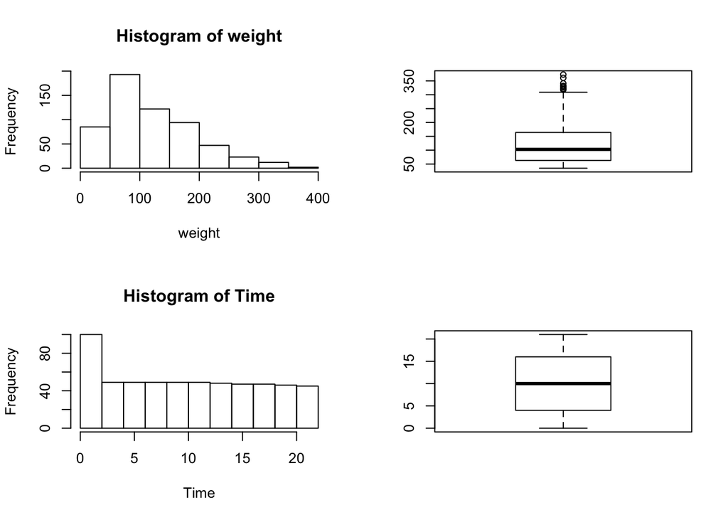

```r
par(mfrow=c(2,2))
hist(weight)
boxplot(weight)
hist(Time)
boxplot(Time)
```

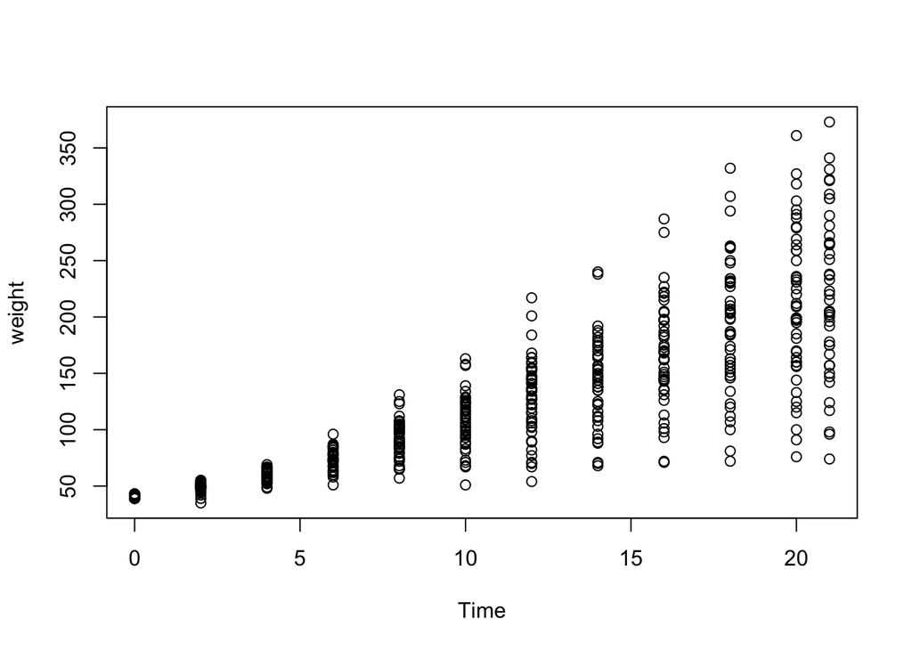

```r
par(mfrow=c(1,1))
plot(Time, weight)
```

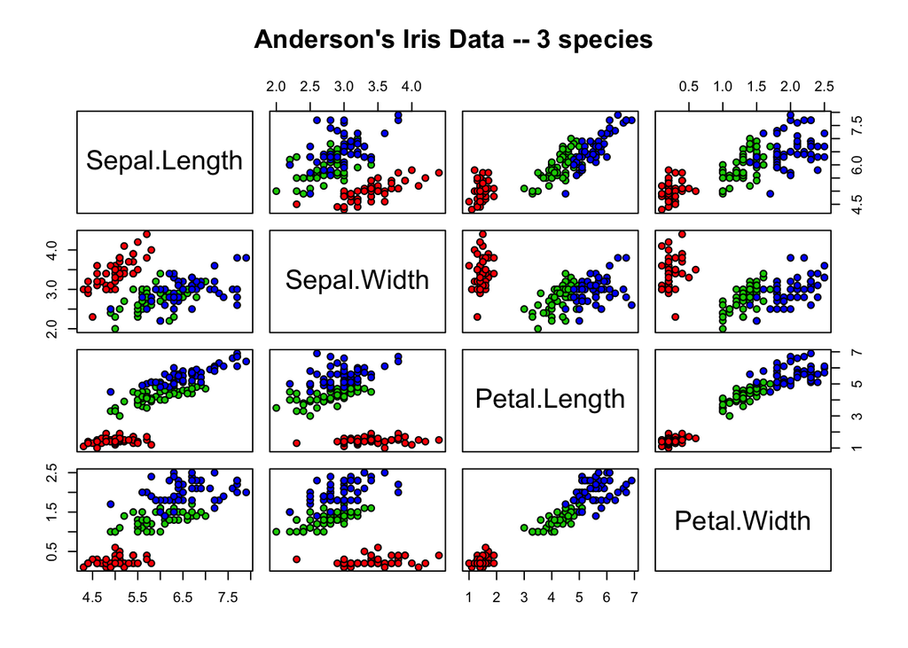

```r
pairs(iris[1:4], main = "Anderson's Iris Data -- 3 species", pch = 21,
      bg = c("red", "green3", "blue")[unclass(iris$Species)])
```

```r
class(trees)
```

```
## [1] "data.frame"
```

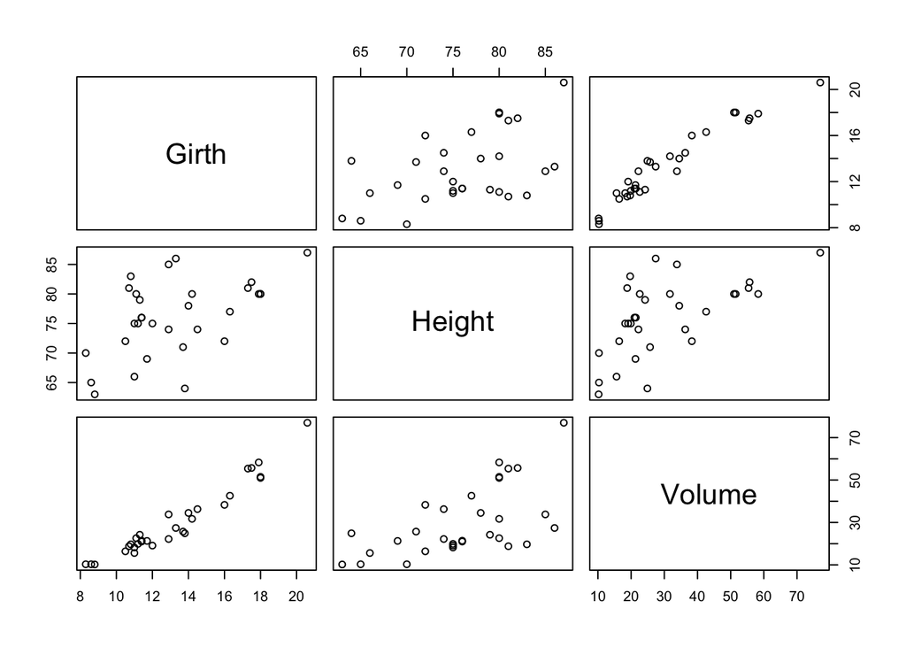

```r
plot(trees)
```

```r
class(faithful)
```

```
## [1] "data.frame"
```

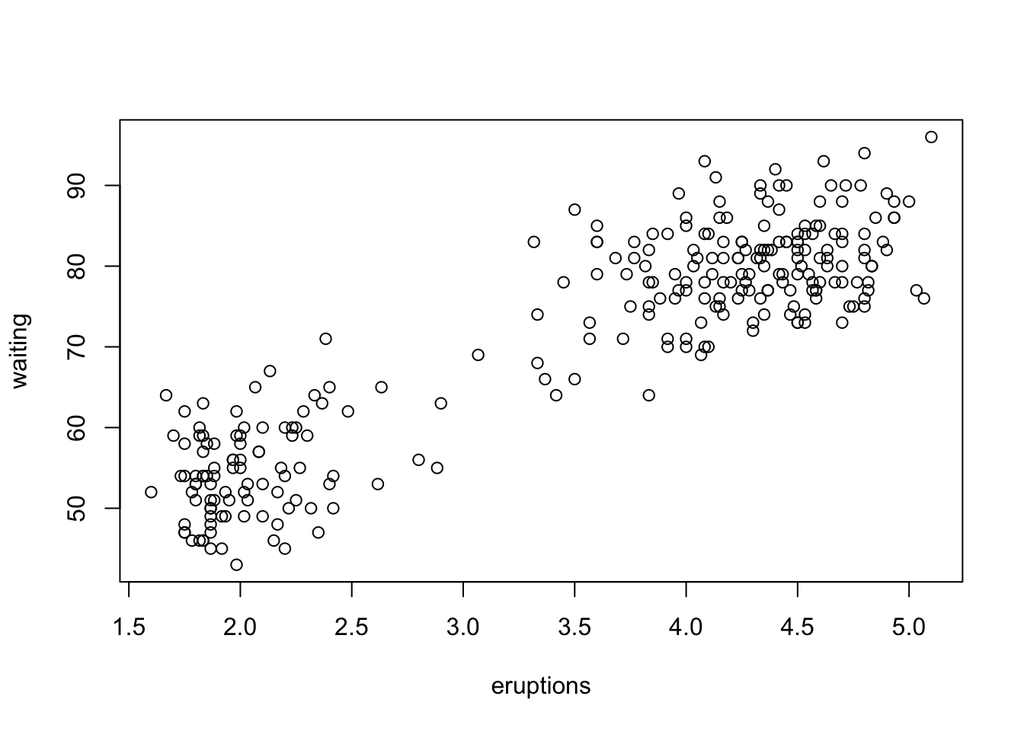

```r
plot(faithful)
```

```r
class(HairEyeColor)
```

```
## [1] "table"
```

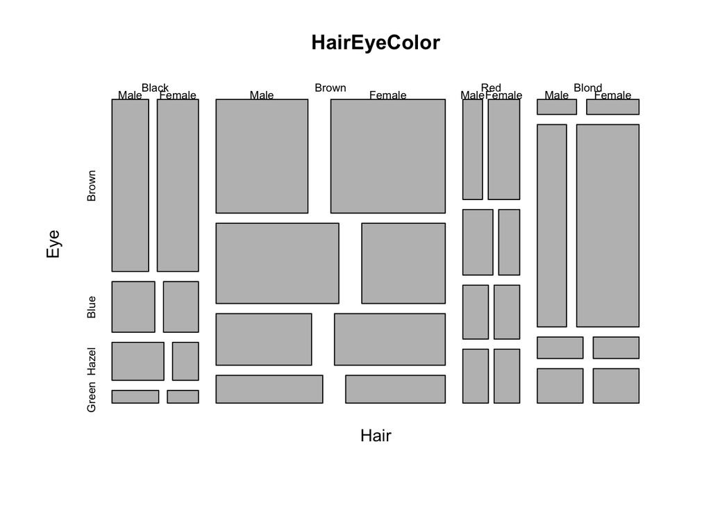

```r
plot(HairEyeColor)
```

```r
class(nhtemp)
```

```
## [1] "ts"
```

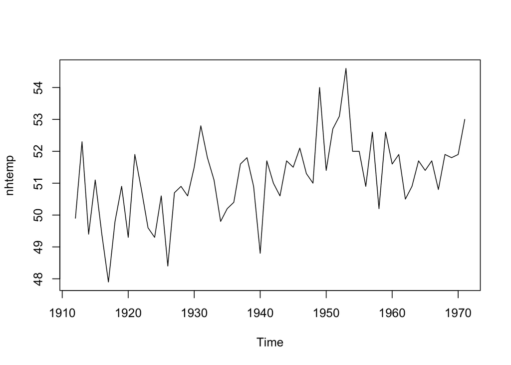

```r
plot(nhtemp)
```

## Writing functions

An important feature of R is the facility to extend the language by writing your own functions.

```r
fnName = function()
{
}
```

Let us write a function for standard deviation

```r
sd1 = function(x){
  sqrt(var(x))
}

x = c(9,5,2,3,7)

sd1(x)
```

```
## [1] 2.863564
```

If we want to change the function, the command `fix(sd1)` will open the function in an editor which we can then use to modify it. We can use this form also to define the function.

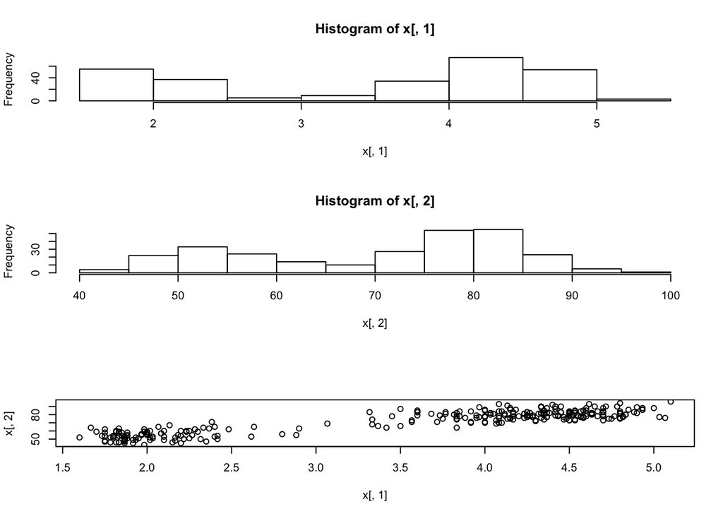

```
##         eruptions waiting
## Min.        1.600    43.0
## 1st Qu.     2.163    58.0
## Median      4.000    76.0
## Mean        3.488    70.9
## 3rd Qu.     4.454    82.0
## Max.        5.100    96.0
```

```r
several.plots<-function(x){
par(mfrow=c(3,1))
hist(x[,1])
hist(x[,2])
plot(x[,1],x[,2])
par(mfrow=c(1,1))
apply(x,2,summary)
}

several.plots(faithful)
```

## Resources

1. Download R http://www.r-project.org
2. Download RStudio IDE http://www.rstudio.com
3. The Comprehensive R Archive Network http://cran.r-project.org/web/packages/
4. Learn R https://www.datacamp.com https://www.datacamp.com/courses/r-programming-with-swirl